# Self-Driving Car Engineer Nanodegree

## Project: Build a Traffic Sign Recognition Classifier

In this notebook, a template is provided for you to implement your functionality in stages, which is required to successfully complete this project. If additional code is required that cannot be included in the notebook, be sure that the Python code is successfully imported and included in your submission if necessary.

In addition to implementing code, there is a writeup to complete. The writeup should be completed in a separate file, which can be either a markdown file or a pdf document. There is a [write up template](https://github.com/udacity/CarND-Traffic-Sign-Classifier-Project/blob/master/writeup_template.md) that can be used to guide the writing process. Completing the code template and writeup template will cover all of the [rubric points](https://review.udacity.com/#!/rubrics/481/view) for this project.

The [rubric](https://review.udacity.com/#!/rubrics/481/view) contains "Stand Out Suggestions" for enhancing the project beyond the minimum requirements. The stand out suggestions are optional. If you decide to pursue the "stand out suggestions", you can include the code in this Ipython notebook and also discuss the results in the writeup file.

> **Note:** Code and Markdown cells can be executed using the **Shift + Enter** keyboard shortcut. In addition, Markdown cells can be edited by typically double-clicking the cell to enter edit mode.

```python
import matplotlib.pyplot as plt
import csv
import pickle
import os
import numpy as np
from PIL import Image
import tensorflow as tf
from tensorflow.keras import layers
from tensorflow.keras.preprocessing.image import ImageDataGenerator, img_to_array
import tensorflow.keras as tk
from tensorflow.keras.utils import to_categorical
from tqdm import tqdm

gpu = tf.config.experimental.list_physical_devices(device_type='GPU')
assert len(gpu) == 1
tf.config.experimental.set_memory_growth(gpu[0], True)

# Path
DATA_PATH = "./data/"  # dataset root path
ORI_PATH = DATA_PATH + 'traffic-signs-data/'
TRAIN_PATH = DATA_PATH + "train/"
VALID_PATH = DATA_PATH + "valid/"
TEST_PATH = DATA_PATH + "test/"
CHECKPOINT_SAVE_PATH = "./checkpoint/mymodel.ckpt"

# Parameters （I comment some parameters because they are of hard-coding)
# N_W = 32 #Width
# N_H = 32 #Height
# N_C = 3  #Color
# N_CLASS = 43

# TRAIN_LEN =  34799
# VALID_LEN = 4410
# TEST_LEN = 12630

BATCH_SIZE = 100
LEARNING_RATE = 0.009
EPOCHS = 40
```

## Step 0: Load The Data

```python
for name in ['test.p', 'valid.p', 'train.p']:
    ori_path = os.path.join(ORI_PATH, name)
    with open(ori_path, mode='rb') as f:
        data = pickle.load(f)
        features, labels = data['features'], data['labels']

        # adding the soft-coding codes
        if name == 'train.p':
            TRAIN_LEN, N_W, N_H, N_C = features.shape
            N_CLASS = np.max(labels)+1
        if name == 'valid.p':
            VALID_LEN, _, _, _ = features.shape
        if name == 'test.p':
            TEST_LEN, _, _, _ = features.shape
        print(TRAIN_LEN, VALID_LEN, TEST_LEN, N_W, N_H, N_C, N_CLASS)


        for i in range(len(features)):
            img = Image.fromarray(features[i])
            label = str(labels[i])

            sava_path = os.path.join(DATA_PATH, name.split('.')[0], label)
            if not os.path.exists(sava_path):
                os.makedirs(sava_path)
            img.save(os.path.join(sava_path, str(i)+'.jpg'))
```

```
34799 4410 12630 32 32 3 43
34799 4410 12630 32 32 3 43
34799 4410 12630 32 32 3 43
```

## Step 1: Dataset Summary & Exploration

The pickled data is a dictionary with 4 key/value pairs:

- `'features'` is a 4D array containing raw pixel data of the traffic sign images, (num examples, width, height, channels).
- `'labels'` is a 1D array containing the label/class id of the traffic sign. The file `signnames.csv` contains id -> name mappings for each id.
- `'sizes'` is a list containing tuples, (width, height) representing the original width and height the image.
- `'coords'` is a list containing tuples, (x1, y1, x2, y2) representing coordinates of a bounding box around the sign in the image. **THESE COORDINATES ASSUME THE ORIGINAL IMAGE. THE PICKLED DATA CONTAINS RESIZED VERSIONS (32 by 32) OF THESE IMAGES**

Complete the basic data summary below. Use python, numpy and/or pandas methods to calculate the data summary rather than hard coding the results. For example, the [pandas shape method](http://pandas.pydata.org/pandas-docs/stable/generated/pandas.DataFrame.shape.html) might be useful for calculating some of the summary results.

### Include an exploratory visualization of the dataset

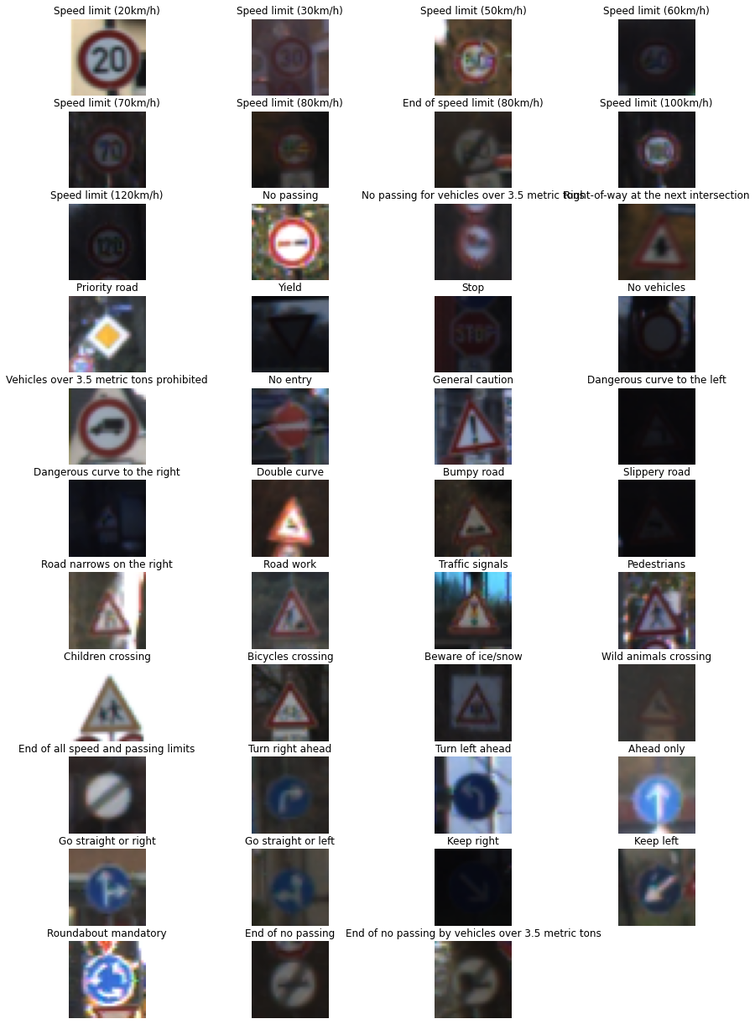

```python
%matplotlib inline

all_labels = []
with open('./signnames.csv', 'r') as csvfile:
    readCSV = csv.reader(csvfile, delimiter=',')
    next(readCSV)
    for row in readCSV:
        all_labels += [row[1]]

plt.figure(figsize=(15, 30))
for label in range(0, N_CLASS):
    plt.subplot(15, 4, label+1)
    feature = features[labels==label]

    plt.imshow(feature[0])
    plt.title(all_labels[label])
    plt.axis('off')
plt.show()
```

### Provide a Basic Summary of the Data Set Using Python, Numpy and/or Pandas

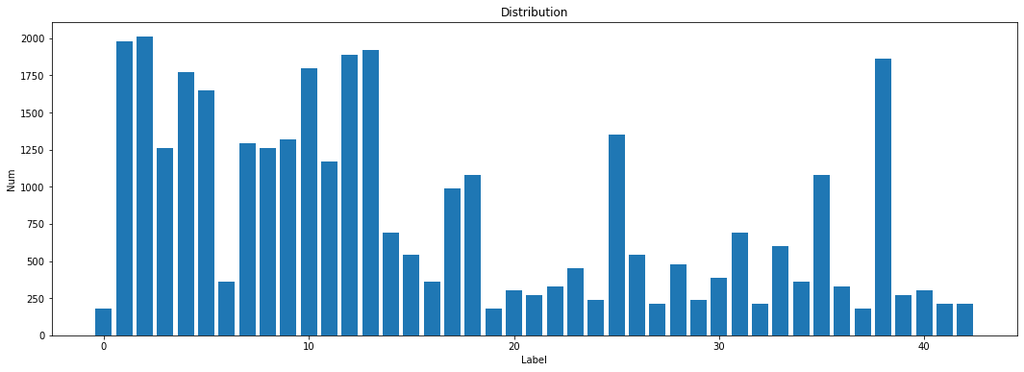

```python
values, counts = np.unique(labels, return_counts=True)
plt.figure(figsize=(18, 6))
plt.bar(values, counts)
plt.ylabel('Num')
plt.xlabel('Label')
plt.title("Distribution")
```

## Step 2: Design and Test a Model Architecture

Design and implement a deep learning model that learns to recognize traffic signs. Train and test your model on the [German Traffic Sign Dataset](http://benchmark.ini.rub.de/?section=gtsrb&subsection=dataset).

The LeNet-5 implementation shown in the classroom at the end of the CNN lesson is a solid starting point. You'll have to change the number of classes and possibly the preprocessing, but aside from that it's plug and play!

With the LeNet-5 solution from the lecture, you should expect a validation set accuracy of about 0.89. To meet specifications, the validation set accuracy will need to be at least 0.93. It is possible to get an even higher accuracy, but 0.93 is the minimum for a successful project submission.

There are various aspects to consider when thinking about this problem:

- Neural network architecture (is the network over or underfitting?)
- Play around preprocessing techniques (normalization, rgb to grayscale, etc)
- Number of examples per label (some have more than others).
- Generate fake data.

Here is an example of a [published baseline model on this problem](http://yann.lecun.com/exdb/publis/pdf/sermanet-ijcnn-11.pdf). It's not required to be familiar with the approach used in the paper but, it's good practice to try to read papers like these.

### Model Architecture

```python
# Design model architecture
class Model():
    def __init__(self, class_num):
        self.class_num = class_num

    def conv(self, x_tensor, filters, conv_ksize=(3, 3), conv_padding='same'):
        res = layers.Conv2D(filters, kernel_size=conv_ksize, padding=conv_padding)(x_tensor)
        return res


    def maxpool(self, x_tensor, pool_strides=(2, 2), pool_padding='same'):
        res = layers.MaxPool2D(pool_size=pool_strides, strides=pool_strides, padding=pool_padding)(x_tensor)
        return res


    def fc(self, x_tensor, num_outputs, activation='relu'):
        res = layers.Dense(num_outputs, activation=activation)(x_tensor)

        if activation=='relu':
            res = layers.BatchNormalization()(res)
            res = layers.Dropout(0.5)(res)

        return res


    def conv_relu(self, x_tensor, filters):
        res = self.conv(x_tensor, filters)
        res = layers.Activation('relu')(res)
        res = layers.BatchNormalization()(res)

        return res



    # Define model architecture
    def mymodel(self):
        image_input = tf.keras.layers.Input(shape=(N_W, N_H, N_C))
        x = self.conv_relu(image_input, 32)
        x = self.conv_relu(x, 32)
        x = self.maxpool(x)
        x = self.conv_relu(x, 64)
        x = self.conv_relu(x, 64)
        x = self.maxpool(x)

        x = layers.Flatten()(x)
        x = self.fc(x, 256, activation='relu')
        x = self.fc(x, self.class_num, activation='softmax')
        res = tf.keras.Model(image_input, x)

        return res
```

## Pre-process image and normaliztion

- Normalize the dataset from [0, 255] to [0, 1]
- One-hot operation to the label

```python
def getdata(PATH):
    print("...loading images...")
    data = []
    labels = []

    for label in os.listdir(PATH):
        label_path = os.path.join(PATH, label)
        for name in os.listdir(label_path):
            img = Image.open(os.path.join(label_path, name))
            img = img.resize((N_W, N_H))
            img = img_to_array(img)
            data.append(img)
            labels.append(int(label))

    # Normalize the dataset, change the pixel value from [0, 255] to [0, 1].
    data = np.array(data, dtype="float") / 255.0
    labels = np.array(labels)
    # One-hot operation to the label
    labels = to_categorical(labels, num_classes=N_CLASS)

    print(data.shape)
    print(labels.shape)


    if PATH == TRAIN_PATH:
        # I comment the data augmendation part, beacuse the result of doing flip to images is  that the prediction accuracy would considerably reduce.
        generator = ImageDataGenerator()# horizontal_flip=True, vertical_flip=True

    else:
        generator = ImageDataGenerator()

    data_gen = generator.flow(data, labels,
                              batch_size=BATCH_SIZE,
                              shuffle=True)

    return data_gen
```

## Train & Validate the Model

```
Model: "functional_9"
_________________________________________________________________
Layer (type)                 Output Shape              Param #
=================================================================
input_5 (InputLayer)         [(None, 32, 32, 3)]       0
_________________________________________________________________
conv2d_16 (Conv2D)           (None, 32, 32, 32)        896
_________________________________________________________________
activation_16 (Activation)   (None, 32, 32, 32)        0
_________________________________________________________________
batch_normalization_20 (Batc (None, 32, 32, 32)        128
_________________________________________________________________
conv2d_17 (Conv2D)           (None, 32, 32, 32)        9248
_________________________________________________________________
activation_17 (Activation)   (None, 32, 32, 32)        0
_________________________________________________________________
batch_normalization_21 (Batc (None, 32, 32, 32)        128
_________________________________________________________________
max_pooling2d_8 (MaxPooling2 (None, 16, 16, 32)        0
_________________________________________________________________
conv2d_18 (Conv2D)           (None, 16, 16, 64)        18496
_________________________________________________________________
activation_18 (Activation)   (None, 16, 16, 64)        0
_________________________________________________________________
batch_normalization_22 (Batc (None, 16, 16, 64)        256
_________________________________________________________________
conv2d_19 (Conv2D)           (None, 16, 16, 64)        36928
_________________________________________________________________
activation_19 (Activation)   (None, 16, 16, 64)        0
_________________________________________________________________
batch_normalization_23 (Batc (None, 16, 16, 64)        256
_________________________________________________________________
max_pooling2d_9 (MaxPooling2 (None, 8, 8, 64)          0
_________________________________________________________________
flatten_4 (Flatten)          (None, 4096)              0
_________________________________________________________________
dense_8 (Dense)              (None, 256)               1048832
_________________________________________________________________
batch_normalization_24 (Batc (None, 256)               1024
_________________________________________________________________
```

[output cut: 50 more lines]

[output not shown]

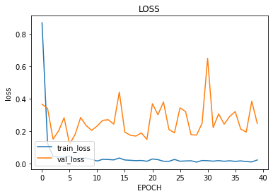

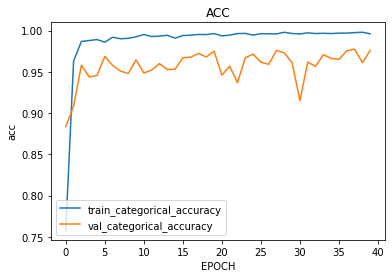

```python
# Model initialization
MYMODEL = Model(N_CLASS)
model = MYMODEL.mymodel()
model.summary()   # show model architechture

# Read data
train_data, valid_data = getdata(TRAIN_PATH), getdata(VALID_PATH)


# Training settings
model.compile(optimizer=tf.keras.optimizers.Adam(learning_rate=LEARNING_RATE),  # Optimition
              loss=tf.keras.losses.CategoricalCrossentropy(from_logits=False),  # Loss function
              metrics=["categorical_accuracy"])   # Metrics

# Breakpoint reconvery
# if os.path.exists(CHECKPOINT_SAVE_PATH + '.index'):
#     print('load the model')
#     model.load_weights(CHECKPOINT_SAVE_PATH)

# Save model
call_back = tk.callbacks.ModelCheckpoint(filepath=CHECKPOINT_SAVE_PATH,   # Saving directory
                                         save_weights_only=True,
                                         save_best_only=True)

# Start training
H = model.fit_generator(train_data,
                    steps_per_epoch=TRAIN_LEN // BATCH_SIZE, epochs=EPOCHS, initial_epoch=0,
                    validation_data=valid_data,
                    validation_steps=VALID_LEN // BATCH_SIZE,
                    callbacks=[call_back])


# Plot the training loss and accuracy curve and save them
# plt.style.use("ggplot")
plt.figure()
plt.plot(range(0, EPOCHS), H.history["loss"], label="train_loss")
plt.plot(range(0, EPOCHS), H.history["val_loss"], label="val_loss")

plt.title("LOSS")
plt.xlabel("EPOCH")
plt.ylabel("loss")
plt.legend(loc="lower left")

plt.figure()
plt.plot(range(0, EPOCHS), H.history["categorical_accuracy"], label="train_categorical_accuracy")
plt.plot(range(0, EPOCHS), H.history["val_categorical_accuracy"], label="val_categorical_accuracy")

plt.title("ACC")
plt.xlabel("EPOCH")
plt.ylabel("acc")
plt.legend(loc="lower left")
```

## Test the model

```python
MYMODEL = Model(N_CLASS)
model = MYMODEL.mymodel()
model.load_weights(CHECKPOINT_SAVE_PATH)

right = 0
all = 0
for label in tqdm(os.listdir(TEST_PATH)):
    label_path = os.path.join(TEST_PATH, label)
    for name in os.listdir(label_path):
        all+=1
        img = Image.open(os.path.join(label_path, name))
        img = img.resize((N_W, N_H))
        img_raw = np.array(img)/255.   # normalization   32*32*3
        img_raw = np.expand_dims(img_raw, axis=0)  # 1*32*32*3

        result = np.argmax(model.predict(img_raw))  # [0.9, 0.1,...,0]

        if result == int(label):
            right+=1
#         print(label, result)
print('acc is:', right/all)
```

```
acc is: 0.9569279493269992
```

## Step 3: Test a Model on New Images

To give yourself more insight into how your model is working, download at least five pictures of German traffic signs from the web and use your model to predict the traffic sign type.

You may find `signnames.csv` useful as it contains mappings from the class id (integer) to the actual sign name.

[output not shown]

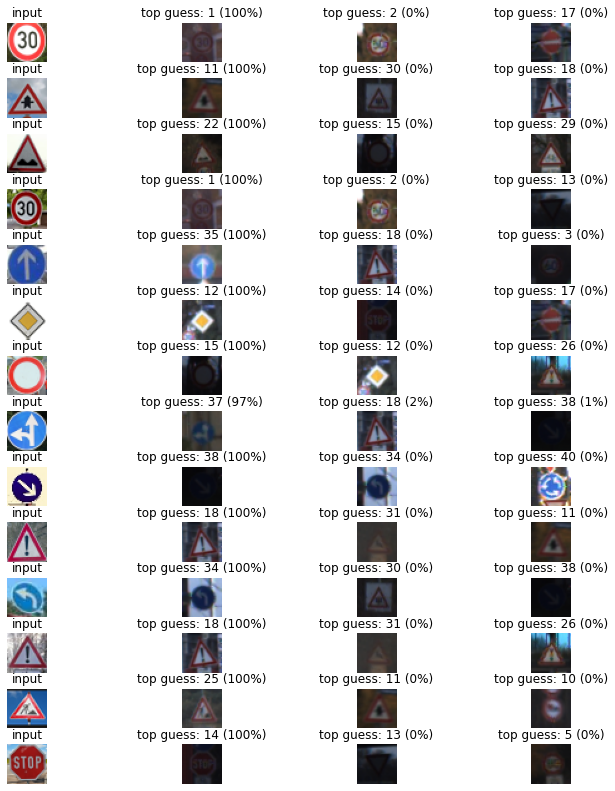

```python
# initialize the model
MYMODEL = Model(N_CLASS)
model = MYMODEL.mymodel()
model.load_weights(CHECKPOINT_SAVE_PATH)


imgpath = './new_image'
path_list = os.listdir(imgpath)
softmax_logits = []
fig, axs = plt.subplots(len(os.listdir(imgpath)),4, figsize=(12, 14))
fig.subplots_adjust(hspace = .4, wspace=.2)
axs = axs.ravel()


for i, name in enumerate(path_list):

    img = Image.open(os.path.join(imgpath, name))
    if img.mode != 'RGB':
        img = img.convert('RGB')
    img = img.resize((N_W, N_H))
    img_raw = np.array(img)/255.
    img_raw = np.expand_dims(img_raw, axis=0)

    result = model.predict(img_raw)[0]
    sort_result = np.argsort(result)
    softmax_logits.append(result)

    axs[4*i].axis('off')
    axs[4*i].imshow(img)
    axs[4*i].set_title('input')

    top1 = sort_result[-1]
    axs[4*i+1].axis('off')
    feature1 = features[labels==top1][0]
    axs[4*i+1].imshow(Image.fromarray(feature1))
    axs[4*i+1].set_title('top guess: {} ({:.0f}%)'.format(top1, 100*result[top1]))


    top2 = sort_result[-2]
    axs[4*i+2].axis('off')
    feature2 = features[labels==top2][0]
    axs[4*i+2].imshow(Image.fromarray(feature2))
    axs[4*i+2].set_title('top guess: {} ({:.0f}%)'.format(top2, 100*result[top2]))


    top3 = sort_result[-3]
    axs[4*i+3].axis('off')
    feature3 = features[labels==top3][0]
    axs[4*i+3].imshow(Image.fromarray(feature3))
    axs[4*i+3].set_title('top guess: {} ({:.0f}%)'.format(top3, 100*result[top3]))
```

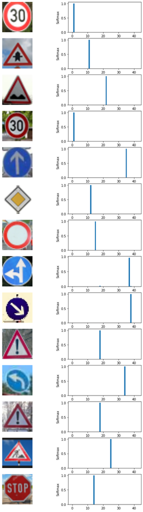

```python
fig, axs = plt.subplots(len(path_list),2, figsize=(9, 29))
axs = axs.ravel()

for i, name in enumerate(path_list):
    img = Image.open(os.path.join(imgpath, name))
    axs[2*i].axis('off')
    axs[2*i].imshow(img)

    axs[2*i+1].bar(range(N_CLASS), softmax_logits[i])
    axs[2*i+1].set_ylabel('Softmax')
```